# Discontinuous Regression and Image Processing

# Jump Regression Models

# Package Overview

The **DRIP** package provides functionality for three categories of image analysis problems: edge detection, edge-preserving noise removal and blind image deblurring. Edge detection is often used in image data compression. Noise removal and image deblurring are important for improving human and machine perception of the images. The package is designed for general image analysis without restrictions on the specific image type. To use **DRIP** in practice, the workflow often involves parameter tuning before model estimation.

```r
library(DRIP)
```

# Step Edge Detection

The step edge detector in **DRIP** is implemented by the `stepEdge()` function. We apply it to the SAR image which is included in the package. The output of `stepEdge()` is a matrix of 0’s and 1’s. It is worth noting that the bandwidth is specified in terms of the number of pixels. Also, we have exchanged 0’s and 1’s in the visualization with the `image()` function in order to have the jump points shown in black.

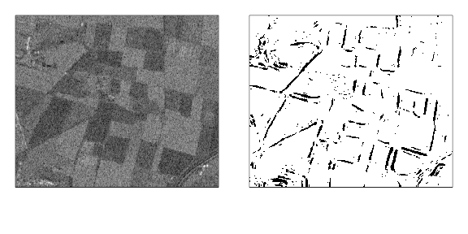

```r
stepedge <- stepEdge(image = sar, bandwidth = 10, thresh = 17,
                     degree = 1)
par(mfrow = c(1, 2), mar = c(3, 1, 1, 1), xaxt = "n", yaxt = "n")
image(sar, col = gray(c(0:255)/255))
image(1 - stepedge, col = gray(c(0:255)/255))
```

Two parameters, bandwidth and threshold, need to be specified by the user. **DRIP** has two functions for this purpose. The first is `edgeParSelPilot()`. Users can specify several preliminary bandwidth values. Since the bandwidth specifies the neighborhood size for local smoothing, positive integers in the range of $[1, 20]$ are usually reasonable candidates. The `edgeParSelPilot()` function would plot the image of the edge detection statistics for each given bandwidth. Users can narrow down the choices based on the visual impression. In addition, the function outputs a few upper quantiles of the edge detection statistics for each bandwidth. Those quantiles offer clues to what reasonable threshold values can be, as edges are usually sparse in an image. In the following illustration with the SAR image, we provide three bandwidths and three probabilities to `edgeParSelPilot()`.

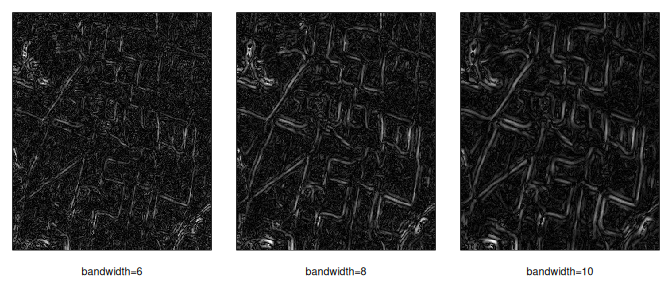

```
#>              probs=0.75 probs=0.85 probs=0.95
#> bandwidth=6   10.688440   13.79875   20.18085
#> bandwidth=8    9.610952   12.59395   19.38523
#> bandwidth=10   9.226387   12.21794   19.25910
```

```r
edgeParSelPilot(sar, edgeType = "step", degree = 1, bandwidth = c(6, 8, 10), probs = c(0.75, 0.85, 0.95))
```

Bandwidth values around 10 seem reasonable as the visualization is less noisy. The quantiles suggest that the threshold should be around 20. Next, users can use the second function, `stepEdgeParSel()`, to finalize the parameter choice. The `stepEdgeParSel()` function implements a bootstrap-based data-driven procedure that estimates the edge detection performance for each combination of the bandwidth and threshold. Since this is a bootstrap procedure, the number of bootstrap samples needs to be given, and a random seed is required to ensure reproducibility. The function returns a matrix of $\widehat{d}_{KQ}$, an edge detection performance measure. It also reports the selected bandwidth and threshold parameters associated with the smallest $\widehat{d}_{KQ}$ value.

```r
set.seed(24)
parSel <- stepEdgeParSel(image = sar, bandwidth = c(9, 10), degree = 1,
                          thresh = c(17, 21), nboot = 10)
print(parSel, type = "all")
```

```
#> The bootstrap matrix:
#>                thresh=17   thresh=21
#> bandwidth=9  0.009777572 0.012336507
#> bandwidth=10 0.008982834 0.011186066
#> The selected bandwidth:  10
#> The selected threshold:  17
```

# Image Denoising

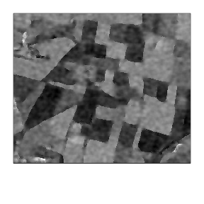

```r
fit <- restore3Stage(image = sar, bandwidth = 4, step_edge = stepedge,
                  roof_edge = array(0, dim(sar)))
par(mfrow = c(1, 1), mar = c(3, 1, 1, 1), xaxt = "n", yaxt = "n")
image(fit, col = gray(c(0:255)/255))
```

This three-stage approach requires a bandwidth parameter. It can be selected by minimizing the leave-one-out cross validation score. The `restore3StageParSel()` function implements the cross validation procedure.

```r
bw_3stage <- restore3StageParSel(image = sar, bandwidth = 4:5,
                              step_edge = stepedge,
                              roof_edge = array(0, dim(sar)))
print(bw_3stage, type = "all")
```

```
#> The cross validation scores:
#>          bandwidth=4 bandwidth=5
#> CV-score    293.0294    300.4995
#> The selected bandwidth:  4
```

# Blind Image Deblurring

In addition to having noise, images may also have blur involved. For instance, in astronomical imaging, ground-based imaging systems are subject to blurring due to the rapidly changing index of refraction of the atmosphere. In photography, out-of-focus or camera shake often results in blurred images. In medical imaging, blurred x-rays or mammograms are almost inevitable because the medical imaging systems limit the intensity of the incident radiation in order to protect the patient’s health. In the image processing literature, a commonly used model to describe the relationship between the original image and its observed but blurred version is
$$Z(x_i, y_j) = G\{f\}(x_i, y_j) + \varepsilon_{i, j},$$
where $G\{f\}$ is the convolution between $g$ and $f$ defined by
$$G\{f\}(x,y) = g\otimes f(x, y) = \int\int_\Omega g(x-u,y-v; x, y)
f(u,v)\; dudv.$$
Here $g$ is called the point spread function. It describes how the original image is spatially degraded (i.e., blurred). In most references, it is further assumed that the blurring is location (or spatially) invariant. That is, $g(u, v;x, y)$ does not depend on $(x, y)$. Blind image deblurring is for estimating $f$ from $Z$ when the point spread function $g$ is not completely specified.

The `jpex()` function implements a blind deblurring method using the jump-preserving extrapolation (JPEX) technique. Here we apply it to a blurry stop-sign image, which is shown below. The function returns a list of two: `deblurred`, the deblurred image, and `edge`, the detected blurry pixels. It can be seen that the JPEX method is able to deblur the image well. The arguments `alpha` and `sigma` specify the significance level and noise level, respectively.

```r
deblur <- jpex(image = stopsign, bandwidth = 2, sigma = 0.00623,
               alpha = 0.001)
names(deblur)
```

```
#> [1] "deblurred" "edge"
```

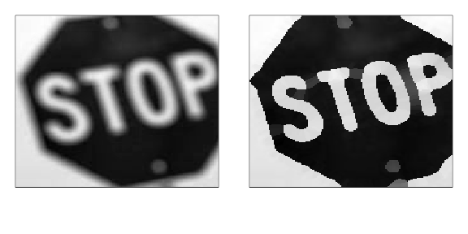

```r
par(mfrow = c(1, 2), mar = c(3, 1, 1, 1), xaxt = "n", yaxt = "n")
image(stopsign, col = gray(c(0:255)/255))
image(deblur$deblurred, col = gray(c(0:255)/255))
```

The `jpex()` function requires a bandwidth value and the noise level. Both can be determined by the `cv.jpex()` function.

```r
cv.out <- cv.jpex(image = stopsign, bandwidths = c(2, 3), ncpus = 1)
print(cv.out, type = "all")
```

```
#> The cross validation scores:
#> [1] 5.591376e-05 1.421656e-04
#> The selected bandwidth:  2
#> The estimated sigma:  0.006231292
```